# Data Visualization: Group 4

PopBio REU 2018

Reni Kaul

We’ve created data visualization using many of the default settings. Today we will spend time exploring different visualizations using the `ggplot2` package. Focus on creating a visualization for presentation.

At a minimum figures should have:

- labeled axes with units
- legend with meaningful labels

# Challenge 1

Today we will explore the `weather` dataset that is part of the `nycflights13` [data package](https://cran.r-project.org/web/packages/nycflights13/nycflights13.pdf). The `weather` dataset consists of hourly meterological data for LGA, JFK and EWR airports for all of 2013. If we were interested in the annual trend in tempature we could make a box plot of the recorded temperatures for each month.

Using base `R`, the code and plot look like this:

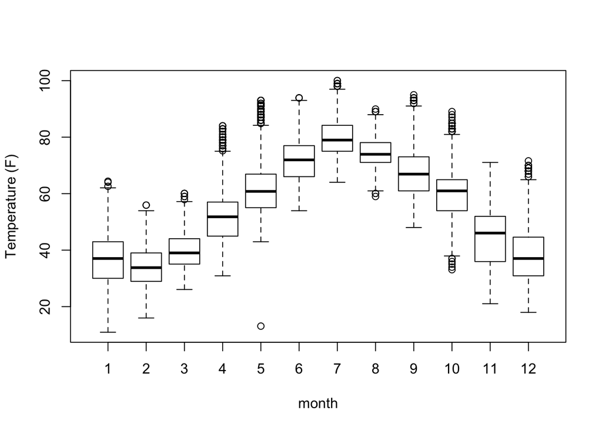

```r
library(nycflights13) #load data from package

boxplot(weather$temp ~ weather$month, xlab="month", ylab="Temperature (F)" ) #instead of assigning x and y values, you can use the syntax y ~ x
```

Today, your challenge is to recreate this figure using the `ggplot2` package. `ggplot2` was first published to CRAN in 2005, so a quick google search will return *MANY* tutorials, discussion pages, etc. The general syntax for boxplots in `ggplot2` is:

```r
ggplot(data, #matrix
       aes(x= X.col, y= Y.col)) + #x and y columns in matrix to plot
      geom_boxplot() #plot the data as a box plot
```

A basic `ggplot2` boxplot should look like this:

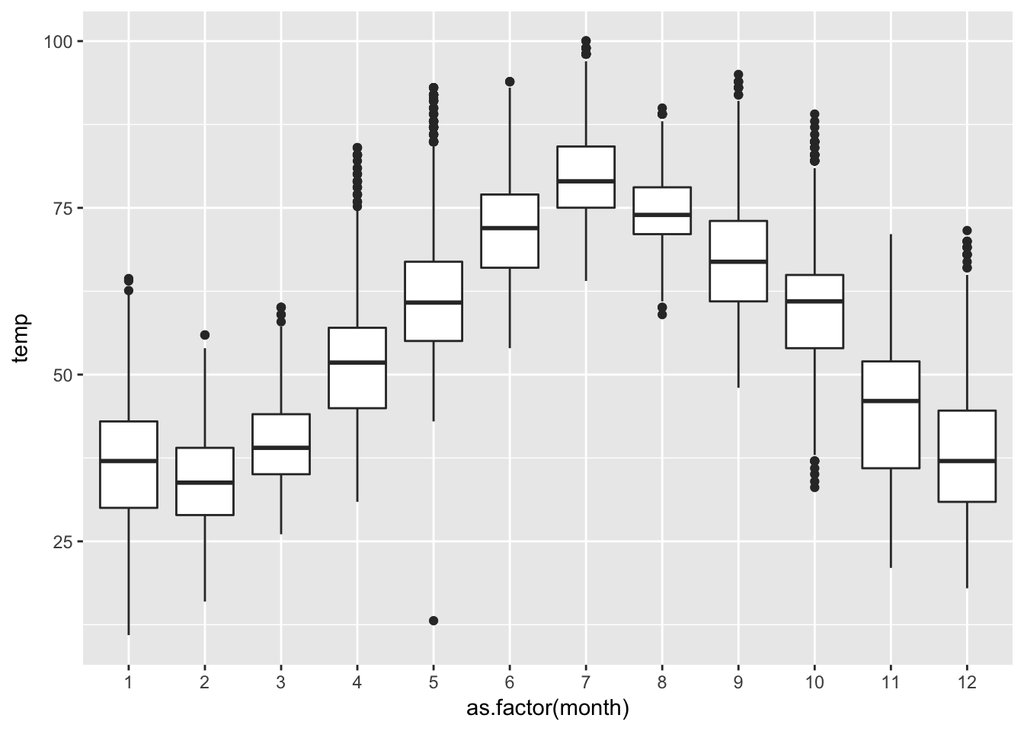

With additional customization, we can produce a plot with a little more shine. For example, this plot has transparent colored boxes and month names instead of numbers.

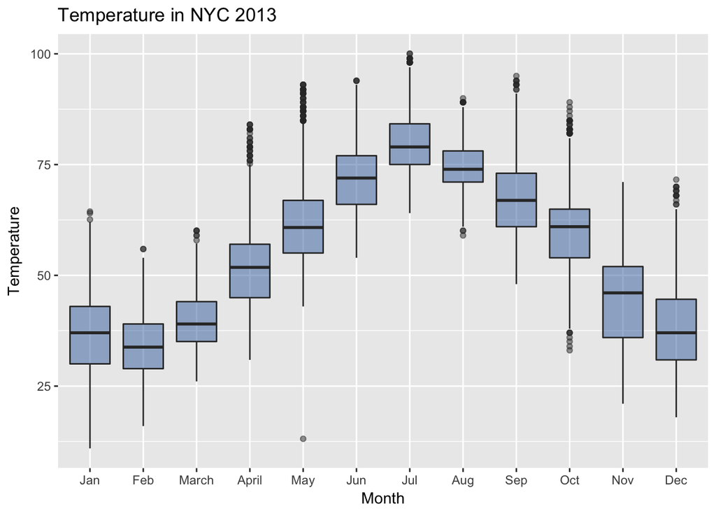

Work with your team to create a polished `ggplot2` boxplot. It doesn’t need to look like these figures, but you are welcome to use them as a guide. If you need guidance, check out the ggplot2 cheat sheet. A very detailed tutorial is on [ZevRoss](http://zevross.com/blog/2014/08/04/beautiful-plotting-in-r-a-ggplot2-cheatsheet-3/). A more formal guide is in the [R for Data Science](http://r4ds.had.co.nz/data-visualisation.html) visualization chapter.

# Challenge 2

For this exercise, we will use `airquality` in the `datasets` package. Install (if needed) and load the `datasets` package. Explore the `airquality` dataset, a daily air quality measurement of NYC in 1973.

The `ggplot2` package can make highly stylized visualizations with relatively few codes of line. Weighted scatterplots are a good example of these visualizations. The figure below is the ozone reading, y-axis, as a function of the day of the month, x-axis, for July, August and September of 1973. The size of the points indicates the wind speed.

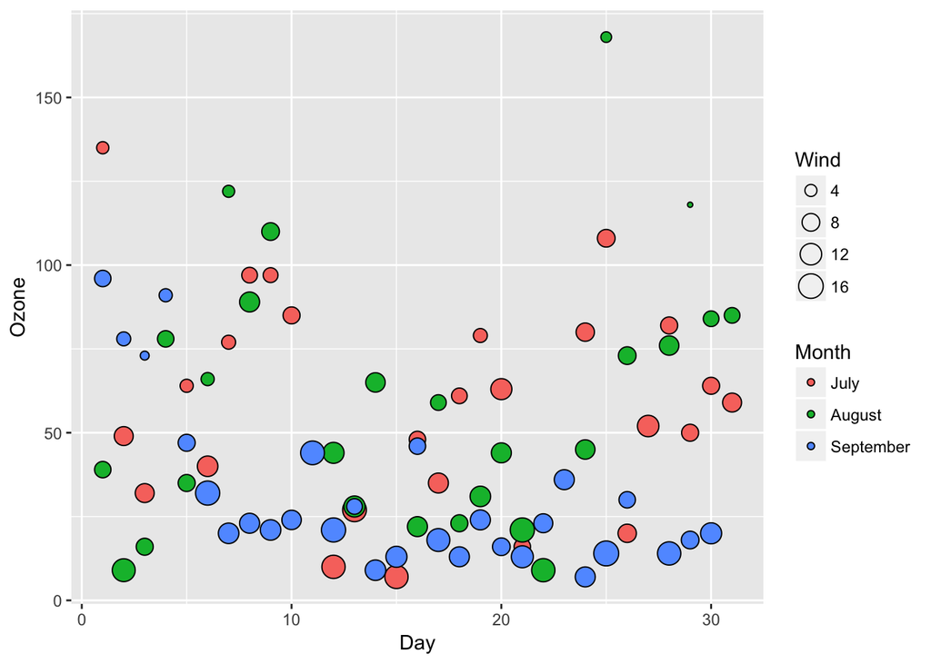

Your goal is to create this figure, and color the points for the 3 different months. The syntax for a scatterplot is similar to a boxplot but `geom_point()` is used in place of `geom_boxplot()`. The first step is to pull out the 3 months of interest from the full `airquality` dataset.